# Risk Factor Analysis

## Outcome Variable

**Outcome Variable:** ever_stunted

## Predictor Variables

**Intervention Variable:** tr

**Adjustment Set:**

unadjusted

## Stratifying Variables

The analysis was stratified on these variable(s):

- agecat
- studyid
- country

## Data Summary

| agecat | studyid | country | ever_stunted | n_cell | n |
| --- | --- | --- | --- | --- | --- |
| 0-6 months | iLiNS_DYADM_LNS | MALAWI | 0 | 33 | 43 |
| 0-6 months | iLiNS_DYADM_LNS | MALAWI | 1 | 10 | 43 |
| 0-6 months | ki1000107-Serrinha-VitA | BRAZIL | 0 | 9 | 10 |
| 0-6 months | ki1000107-Serrinha-VitA | BRAZIL | 1 | 1 | 10 |
| 0-6 months | ki1000110-WASH-Bangladesh | BANGLADESH | 0 | 209 | 232 |
| 0-6 months | ki1000110-WASH-Bangladesh | BANGLADESH | 1 | 23 | 232 |
| 0-6 months | ki1000111-WASH-Kenya | KENYA | 0 | 85 | 92 |
| 0-6 months | ki1000111-WASH-Kenya | KENYA | 1 | 7 | 92 |
| 0-6 months | ki1000125-AgaKhanUniv | PAKISTAN | 0 | 215 | 292 |
| 0-6 months | ki1000125-AgaKhanUniv | PAKISTAN | 1 | 77 | 292 |
| 0-6 months | ki1000304-EU | INDIA | 0 | 7 | 14 |
| 0-6 months | ki1000304-EU | INDIA | 1 | 7 | 14 |
| 0-6 months | ki1000304-VITAMIN-A | INDIA | 0 | 227 | 334 |
| 0-6 months | ki1000304-VITAMIN-A | INDIA | 1 | 107 | 334 |
| 0-6 months | ki1000304-Vitamin-B12 | INDIA | 0 | 1 | 1 |
| 0-6 months | ki1000304-Vitamin-B12 | INDIA | 1 | 0 | 1 |
| 0-6 months | ki1000304-ZnMort | INDIA | 0 | 109 | 181 |
| 0-6 months | ki1000304-ZnMort | INDIA | 1 | 72 | 181 |
| 0-6 months | ki1000304b-SAS-CompFeed | INDIA | 0 | 569 | 792 |
| 0-6 months | ki1000304b-SAS-CompFeed | INDIA | 1 | 223 | 792 |
| 0-6 months | ki1000304b-SAS-FoodSuppl | INDIA | 0 | 257 | 416 |
| 0-6 months | ki1000304b-SAS-FoodSuppl | INDIA | 1 | 159 | 416 |
| 0-6 months | ki1017093b-PROVIDE | BANGLADESH | 0 | 551 | 640 |
| 0-6 months | ki1017093b-PROVIDE | BANGLADESH | 1 | 89 | 640 |
| 0-6 months | ki1066203-TanzaniaChild2 | TANZANIA, UNITED REPUBLIC OF | 0 | 2075 | 2234 |
| 0-6 months | ki1066203-TanzaniaChild2 | TANZANIA, UNITED REPUBLIC OF | 1 | 159 | 2234 |
| 0-6 months | ki1112895-Burkina Faso Zn | BURKINA FASO | 0 | 41 | 46 |
| 0-6 months | ki1112895-Burkina Faso Zn | BURKINA FASO | 1 | 5 | 46 |
| 0-6 months | ki1112895-Guatemala BSC | GUATEMALA | 0 | 186 | 241 |
| 0-6 months | ki1112895-Guatemala BSC | GUATEMALA | 1 | 55 | 241 |

[output cut: 66 more lines]

The following strata were considered:

- agecat: 0-6 months, studyid: iLiNS_DYADM_LNS, country: MALAWI
- agecat: 0-6 months, studyid: ki1000107-Serrinha-VitA, country: BRAZIL
- agecat: 0-6 months, studyid: ki1000110-WASH-Bangladesh, country: BANGLADESH
- agecat: 0-6 months, studyid: ki1000111-WASH-Kenya, country: KENYA
- agecat: 0-6 months, studyid: ki1000125-AgaKhanUniv, country: PAKISTAN
- agecat: 0-6 months, studyid: ki1000304-EU, country: INDIA
- agecat: 0-6 months, studyid: ki1000304-VITAMIN-A, country: INDIA
- agecat: 0-6 months, studyid: ki1000304-Vitamin-B12, country: INDIA
- agecat: 0-6 months, studyid: ki1000304-ZnMort, country: INDIA
- agecat: 0-6 months, studyid: ki1000304b-SAS-CompFeed, country: INDIA
- agecat: 0-6 months, studyid: ki1000304b-SAS-FoodSuppl, country: INDIA
- agecat: 0-6 months, studyid: ki1017093b-PROVIDE, country: BANGLADESH
- agecat: 0-6 months, studyid: ki1066203-TanzaniaChild2, country: TANZANIA, UNITED REPUBLIC OF
- agecat: 0-6 months, studyid: ki1112895-Burkina Faso Zn, country: BURKINA FASO
- agecat: 0-6 months, studyid: ki1112895-Guatemala BSC, country: GUATEMALA
- agecat: 0-6 months, studyid: ki1119695-PROBIT, country: BELARUS
- agecat: 0-6 months, studyid: ki1126311-ZVITAMBO, country: ZIMBABWE
- agecat: 0-6 months, studyid: ki1135781-COHORTS, country: GUATEMALA
- agecat: 0-6 months, studyid: ki1148112-iLiNS-DOSE, country: MALAWI
- agecat: 0-6 months, studyid: ki1148112-iLiNS-DYAD-M, country: MALAWI
- agecat: 0-6 months, studyid: ki1148112-LCNI-5, country: MALAWI
- agecat: 0-6 months, studyid: kiGH5241-JiVitA-3, country: BANGLADESH
- agecat: 0-6 months, studyid: kiGH5241-JiVitA-4, country: BANGLADESH
- agecat: 6-24 months, studyid: iLiNS_DYADM_LNS, country: MALAWI
- agecat: 6-24 months, studyid: iLiNS-Zinc_ZvLNS, country: BURKINA FASO
- agecat: 6-24 months, studyid: ki1000107-Serrinha-VitA, country: BRAZIL
- agecat: 6-24 months, studyid: ki1000110-WASH-Bangladesh, country: BANGLADESH
- agecat: 6-24 months, studyid: ki1000111-WASH-Kenya, country: KENYA
- agecat: 6-24 months, studyid: ki1000125-AgaKhanUniv, country: PAKISTAN
- agecat: 6-24 months, studyid: ki1000304-EU, country: INDIA
- agecat: 6-24 months, studyid: ki1000304-VITAMIN-A, country: INDIA
- agecat: 6-24 months, studyid: ki1000304-Vitamin-B12, country: INDIA
- agecat: 6-24 months, studyid: ki1000304-ZnMort, country: INDIA
- agecat: 6-24 months, studyid: ki1000304b-SAS-CompFeed, country: INDIA
- agecat: 6-24 months, studyid: ki1000304b-SAS-FoodSuppl, country: INDIA
- agecat: 6-24 months, studyid: ki1017093b-PROVIDE, country: BANGLADESH
- agecat: 6-24 months, studyid: ki1066203-TanzaniaChild2, country: TANZANIA, UNITED REPUBLIC OF
- agecat: 6-24 months, studyid: ki1112895-Burkina Faso Zn, country: BURKINA FASO
- agecat: 6-24 months, studyid: ki1112895-Guatemala BSC, country: GUATEMALA
- agecat: 6-24 months, studyid: ki1112895-iLiNS-Zinc, country: BURKINA FASO
- agecat: 6-24 months, studyid: ki1119695-PROBIT, country: BELARUS
- agecat: 6-24 months, studyid: ki1126311-ZVITAMBO, country: ZIMBABWE
- agecat: 6-24 months, studyid: ki1135781-COHORTS, country: GUATEMALA
- agecat: 6-24 months, studyid: ki1148112-iLiNS-DOSE, country: MALAWI
- agecat: 6-24 months, studyid: ki1148112-iLiNS-DYAD-M, country: MALAWI
- agecat: 6-24 months, studyid: ki1148112-LCNI-5, country: MALAWI
- agecat: 6-24 months, studyid: kiGH5241-JiVitA-3, country: BANGLADESH
- agecat: 6-24 months, studyid: kiGH5241-JiVitA-4, country: BANGLADESH

### Dropped Strata

Some strata were dropped due to rare outcomes:

- agecat: 0-6 months, studyid: ki1000107-Serrinha-VitA, country: BRAZIL
- agecat: 0-6 months, studyid: ki1000304-Vitamin-B12, country: INDIA

## Methods Detail

We’re interested in the causal parameters $E[Y_a]$ for all values of $a \in \mathcal{A}$. These parameters represent the mean outcome if, possibly contrary to fact, we intervened to set all units to have $A=a$. Under the randomization and positivity assumptions, these are identified by the statistical parameters $\psi_a=E_W[E_{Y|A,W}(Y|A=a,W)]$. In addition, we’re interested in the mean of $Y$, $E[Y]$ under no intervention (the observed mean). We will estimate these parameters by using SuperLearner to fit the relevant likelihood factors – $E_{Y|A,W}(Y|A=a,W)$ and $p(A=a|W)$, and then updating our likelihood fit using a joint TMLE.

For unadjusted analyses ($W=\{\}$), initial likelihoods were estimated using Lrnr_glm to estimate the simple $E(Y|A)$ and Lrnr_mean to estimate $p(A)$. For adjusted analyses, a small library containing Lrnr_glmnet, Lrnr_xgboost, and Lrnr_mean was used.

Having estimated these parameters, we will then use the delta method to estimate relative risks and attributable risks relative to a prespecified baseline level of $A$.

# Results Detail

## Results Plots

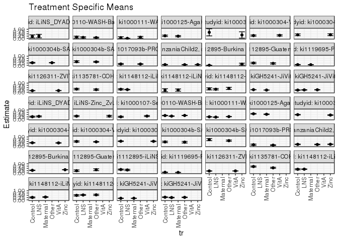

[figure not shown]

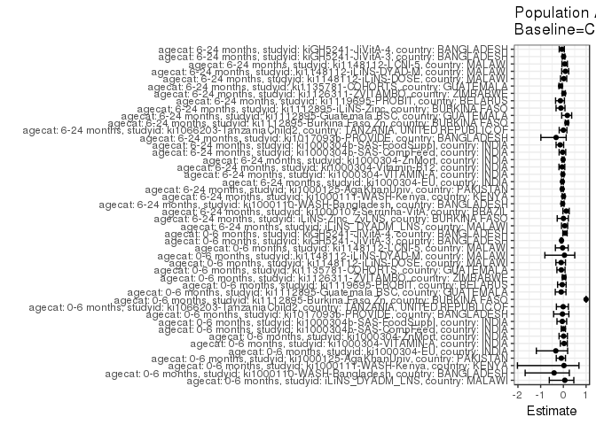

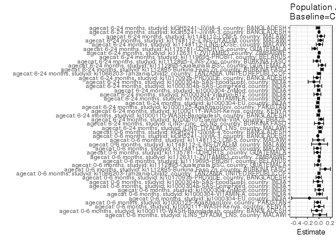

## Results Table

### Parameter: TSM

| agecat | studyid | country | intervention_level | baseline_level | estimate | ci_lower | ci_upper |
| --- | --- | --- | --- | --- | --- | --- | --- |
| 0-6 months | iLiNS_DYADM_LNS | MALAWI | Control | NA | 0.2173913 | 0.0468274 | 0.3879552 |
| 0-6 months | iLiNS_DYADM_LNS | MALAWI | LNS | NA | 0.2500000 | 0.0579814 | 0.4420186 |
| 0-6 months | ki1000110-WASH-Bangladesh | BANGLADESH | Control | NA | 0.1395349 | 0.0357438 | 0.2433259 |
| 0-6 months | ki1000110-WASH-Bangladesh | BANGLADESH | LNS | NA | 0.1014493 | 0.0300560 | 0.1728426 |
| 0-6 months | ki1000110-WASH-Bangladesh | BANGLADESH | Other | NA | 0.0833333 | 0.0337757 | 0.1328910 |
| 0-6 months | ki1000111-WASH-Kenya | KENYA | Control | NA | 0.0740741 | -0.0252514 | 0.1733996 |
| 0-6 months | ki1000111-WASH-Kenya | KENYA | LNS | NA | 0.0000000 | 0.0000000 | 0.0000000 |
| 0-6 months | ki1000111-WASH-Kenya | KENYA | Other | NA | 0.1190476 | 0.0205710 | 0.2175243 |
| 0-6 months | ki1000125-AgaKhanUniv | PAKISTAN | Control | NA | 0.2877698 | 0.2123790 | 0.3631606 |
| 0-6 months | ki1000125-AgaKhanUniv | PAKISTAN | Maternal | NA | 0.2418301 | 0.1738650 | 0.3097951 |
| 0-6 months | ki1000304-EU | INDIA | Control | NA | 0.6666667 | 0.2752327 | 1.0581007 |
| 0-6 months | ki1000304-EU | INDIA | Zinc | NA | 0.3750000 | 0.0268623 | 0.7231377 |
| 0-6 months | ki1000304-VITAMIN-A | INDIA | Control | NA | 0.3099415 | 0.2405216 | 0.3793614 |
| 0-6 months | ki1000304-VITAMIN-A | INDIA | VitA | NA | 0.3312883 | 0.2589234 | 0.4036532 |
| 0-6 months | ki1000304-ZnMort | INDIA | Control | NA | 0.3932584 | 0.2914938 | 0.4950231 |
| 0-6 months | ki1000304-ZnMort | INDIA | Zinc | NA | 0.4021739 | 0.3017004 | 0.5026474 |
| 0-6 months | ki1000304b-SAS-CompFeed | INDIA | Control | NA | 0.2806540 | 0.2373440 | 0.3239639 |
| 0-6 months | ki1000304b-SAS-CompFeed | INDIA | Other | NA | 0.2823529 | 0.2603472 | 0.3043586 |
| 0-6 months | ki1000304b-SAS-FoodSuppl | INDIA | Control | NA | 0.4000000 | 0.3061830 | 0.4938170 |
| 0-6 months | ki1000304b-SAS-FoodSuppl | INDIA | Other | NA | 0.3762058 | 0.3223014 | 0.4301102 |
| 0-6 months | ki1017093b-PROVIDE | BANGLADESH | Control | NA | 0.1445783 | 0.0910387 | 0.1981179 |
| 0-6 months | ki1017093b-PROVIDE | BANGLADESH | Other | NA | 0.1371308 | 0.1061396 | 0.1681220 |
| 0-6 months | ki1066203-TanzaniaChild2 | TANZANIA, UNITED REPUBLIC OF | Control | NA | 0.0718133 | 0.0503677 | 0.0932589 |
| 0-6 months | ki1066203-TanzaniaChild2 | TANZANIA, UNITED REPUBLIC OF | Other | NA | 0.0648649 | 0.0443702 | 0.0853595 |
| 0-6 months | ki1066203-TanzaniaChild2 | TANZANIA, UNITED REPUBLIC OF | Zinc | NA | 0.0739750 | 0.0586570 | 0.0892931 |
| 0-6 months | ki1112895-Burkina Faso Zn | BURKINA FASO | Control | NA | 0.0000000 | 0.0000000 | 0.0000000 |
| 0-6 months | ki1112895-Burkina Faso Zn | BURKINA FASO | Zinc | NA | 0.1282051 | 0.0221215 | 0.2342887 |
| 0-6 months | ki1112895-Guatemala BSC | GUATEMALA | Control | NA | 0.2500000 | 0.1723644 | 0.3276356 |
| 0-6 months | ki1112895-Guatemala BSC | GUATEMALA | Other | NA | 0.2066116 | 0.1343215 | 0.2789016 |
| 0-6 months | ki1119695-PROBIT | BELARUS | Control | NA | 0.0682721 | 0.0491625 | 0.0873817 |

[output cut: 72 more lines]

### Parameter: E(Y)

| agecat | studyid | country | intervention_level | baseline_level | estimate | ci_lower | ci_upper |
| --- | --- | --- | --- | --- | --- | --- | --- |
| 0-6 months | iLiNS_DYADM_LNS | MALAWI | NA | NA | 0.2325581 | 0.1047931 | 0.3603232 |
| 0-6 months | ki1000110-WASH-Bangladesh | BANGLADESH | NA | NA | 0.0991379 | 0.0605998 | 0.1376761 |
| 0-6 months | ki1000111-WASH-Kenya | KENYA | NA | NA | 0.0760870 | 0.0216119 | 0.1305621 |
| 0-6 months | ki1000125-AgaKhanUniv | PAKISTAN | NA | NA | 0.2636986 | 0.2130715 | 0.3143258 |
| 0-6 months | ki1000304-EU | INDIA | NA | NA | 0.5000000 | 0.2282019 | 0.7717981 |
| 0-6 months | ki1000304-VITAMIN-A | INDIA | NA | NA | 0.3203593 | 0.2702424 | 0.3704762 |
| 0-6 months | ki1000304-ZnMort | INDIA | NA | NA | 0.3977901 | 0.3262889 | 0.4692912 |
| 0-6 months | ki1000304b-SAS-CompFeed | INDIA | NA | NA | 0.2815657 | 0.2581773 | 0.3049540 |
| 0-6 months | ki1000304b-SAS-FoodSuppl | INDIA | NA | NA | 0.3822115 | 0.3354600 | 0.4289631 |
| 0-6 months | ki1017093b-PROVIDE | BANGLADESH | NA | NA | 0.1390625 | 0.1122345 | 0.1658905 |
| 0-6 months | ki1066203-TanzaniaChild2 | TANZANIA, UNITED REPUBLIC OF | NA | NA | 0.0711728 | 0.0605086 | 0.0818370 |
| 0-6 months | ki1112895-Burkina Faso Zn | BURKINA FASO | NA | NA | 0.1086957 | 0.0177544 | 0.1996369 |
| 0-6 months | ki1112895-Guatemala BSC | GUATEMALA | NA | NA | 0.2282158 | 0.1751196 | 0.2813119 |
| 0-6 months | ki1119695-PROBIT | BELARUS | NA | NA | 0.0649985 | 0.0530039 | 0.0769930 |
| 0-6 months | ki1126311-ZVITAMBO | ZIMBABWE | NA | NA | 0.1752362 | 0.1674257 | 0.1830467 |
| 0-6 months | ki1135781-COHORTS | GUATEMALA | NA | NA | 0.3120805 | 0.2593852 | 0.3647759 |
| 0-6 months | ki1148112-iLiNS-DOSE | MALAWI | NA | NA | 0.2907268 | 0.2649914 | 0.3164623 |
| 0-6 months | ki1148112-iLiNS-DYAD-M | MALAWI | NA | NA | 0.2285714 | 0.1294923 | 0.3276506 |
| 0-6 months | ki1148112-LCNI-5 | MALAWI | NA | NA | 0.3566176 | 0.2995882 | 0.4136471 |
| 0-6 months | kiGH5241-JiVitA-3 | BANGLADESH | NA | NA | 0.2559533 | 0.2487104 | 0.2631962 |
| 0-6 months | kiGH5241-JiVitA-4 | BANGLADESH | NA | NA | 0.2519702 | 0.2379258 | 0.2660146 |
| 6-24 months | iLiNS_DYADM_LNS | MALAWI | NA | NA | 0.2834008 | 0.2435562 | 0.3232455 |
| 6-24 months | iLiNS-Zinc_ZvLNS | BURKINA FASO | NA | NA | 0.3265802 | 0.2600546 | 0.3931059 |
| 6-24 months | ki1000107-Serrinha-VitA | BRAZIL | NA | NA | 0.2941176 | 0.2538559 | 0.3343794 |
| 6-24 months | ki1000110-WASH-Bangladesh | BANGLADESH | NA | NA | 0.3809325 | 0.3671687 | 0.3946962 |
| 6-24 months | ki1000111-WASH-Kenya | KENYA | NA | NA | 0.2549819 | 0.2444850 | 0.2654787 |
| 6-24 months | ki1000125-AgaKhanUniv | PAKISTAN | NA | NA | 0.5574250 | 0.5310854 | 0.5837646 |
| 6-24 months | ki1000304-EU | INDIA | NA | NA | 0.4661355 | 0.4443109 | 0.4879600 |
| 6-24 months | ki1000304-VITAMIN-A | INDIA | NA | NA | 0.3499462 | 0.3322420 | 0.3676504 |
| 6-24 months | ki1000304-Vitamin-B12 | INDIA | NA | NA | 0.4726368 | 0.4381058 | 0.5071678 |
| 6-24 months | ki1000304-ZnMort | INDIA | NA | NA | 0.5223720 | 0.4996352 | 0.5451087 |
| 6-24 months | ki1000304b-SAS-CompFeed | INDIA | NA | NA | 0.4370016 | 0.3770013 | 0.4970019 |
| 6-24 months | ki1000304b-SAS-FoodSuppl | INDIA | NA | NA | 0.6172840 | 0.5560459 | 0.6785220 |
| 6-24 months | ki1017093b-PROVIDE | BANGLADESH | NA | NA | 0.1081871 | 0.0752189 | 0.1411554 |
| 6-24 months | ki1066203-TanzaniaChild2 | TANZANIA, UNITED REPUBLIC OF | NA | NA | 0.1827243 | 0.1648967 | 0.2005518 |
| 6-24 months | ki1112895-Burkina Faso Zn | BURKINA FASO | NA | NA | 0.3398072 | 0.3288332 | 0.3507812 |
| 6-24 months | ki1112895-Guatemala BSC | GUATEMALA | NA | NA | 0.2967033 | 0.2301546 | 0.3632520 |
| 6-24 months | ki1112895-iLiNS-Zinc | BURKINA FASO | NA | NA | 0.3384380 | 0.2882099 | 0.3886661 |
| 6-24 months | ki1119695-PROBIT | BELARUS | NA | NA | 0.0594777 | 0.0476257 | 0.0713298 |
| 6-24 months | ki1126311-ZVITAMBO | ZIMBABWE | NA | NA | 0.2171741 | 0.2083603 | 0.2259879 |
| 6-24 months | ki1135781-COHORTS | GUATEMALA | NA | NA | 0.6278586 | 0.5846160 | 0.6711013 |
| 6-24 months | ki1148112-iLiNS-DOSE | MALAWI | NA | NA | 0.4110054 | 0.3858622 | 0.4361487 |
| 6-24 months | ki1148112-iLiNS-DYAD-M | MALAWI | NA | NA | 0.2930355 | 0.2606423 | 0.3254286 |
| 6-24 months | ki1148112-LCNI-5 | MALAWI | NA | NA | 0.5260274 | 0.4897810 | 0.5622738 |
| 6-24 months | kiGH5241-JiVitA-3 | BANGLADESH | NA | NA | 0.1731775 | 0.1636227 | 0.1827322 |
| 6-24 months | kiGH5241-JiVitA-4 | BANGLADESH | NA | NA | 0.2728958 | 0.2544375 | 0.2913540 |

### Parameter: RR

| agecat | studyid | country | intervention_level | baseline_level | estimate | ci_lower | ci_upper |
| --- | --- | --- | --- | --- | --- | --- | --- |
| 0-6 months | iLiNS_DYADM_LNS | MALAWI | Control | Control | 1.0000000 | 1.0000000 | 1.0000000 |
| 0-6 months | iLiNS_DYADM_LNS | MALAWI | LNS | Control | 1.1500000 | 0.3835817 | 3.4477660 |
| 0-6 months | ki1000110-WASH-Bangladesh | BANGLADESH | Control | Control | 1.0000000 | 1.0000000 | 1.0000000 |
| 0-6 months | ki1000110-WASH-Bangladesh | BANGLADESH | LNS | Control | 0.7270531 | 0.2611306 | 2.0242986 |
| 0-6 months | ki1000110-WASH-Bangladesh | BANGLADESH | Other | Control | 0.5972222 | 0.2304307 | 1.5478597 |
| 0-6 months | ki1000111-WASH-Kenya | KENYA | Control | Control | 1.0000000 | 1.0000000 | 1.0000000 |
| 0-6 months | ki1000111-WASH-Kenya | KENYA | LNS | Control | 0.0000000 | 0.0000000 | 0.0000002 |
| 0-6 months | ki1000111-WASH-Kenya | KENYA | Other | Control | 1.6071429 | 0.3325178 | 7.7677287 |
| 0-6 months | ki1000125-AgaKhanUniv | PAKISTAN | Control | Control | 1.0000000 | 1.0000000 | 1.0000000 |
| 0-6 months | ki1000125-AgaKhanUniv | PAKISTAN | Maternal | Control | 0.8403595 | 0.5722721 | 1.2340354 |
| 0-6 months | ki1000304-EU | INDIA | Control | Control | 1.0000000 | 1.0000000 | 1.0000000 |
| 0-6 months | ki1000304-EU | INDIA | Zinc | Control | 0.5625000 | 0.1875288 | 1.6872413 |
| 0-6 months | ki1000304-VITAMIN-A | INDIA | Control | Control | 1.0000000 | 1.0000000 | 1.0000000 |
| 0-6 months | ki1000304-VITAMIN-A | INDIA | VitA | Control | 1.0688737 | 0.7817254 | 1.4614991 |
| 0-6 months | ki1000304-ZnMort | INDIA | Control | Control | 1.0000000 | 1.0000000 | 1.0000000 |
| 0-6 months | ki1000304-ZnMort | INDIA | Zinc | Control | 1.0226708 | 0.7137148 | 1.4653690 |
| 0-6 months | ki1000304b-SAS-CompFeed | INDIA | Control | Control | 1.0000000 | 1.0000000 | 1.0000000 |
| 0-6 months | ki1000304b-SAS-CompFeed | INDIA | Other | Control | 1.0060537 | 0.8465611 | 1.1955948 |
| 0-6 months | ki1000304b-SAS-FoodSuppl | INDIA | Control | Control | 1.0000000 | 1.0000000 | 1.0000000 |
| 0-6 months | ki1000304b-SAS-FoodSuppl | INDIA | Other | Control | 0.9405145 | 0.7144982 | 1.2380261 |
| 0-6 months | ki1017093b-PROVIDE | BANGLADESH | Control | Control | 1.0000000 | 1.0000000 | 1.0000000 |
| 0-6 months | ki1017093b-PROVIDE | BANGLADESH | Other | Control | 0.9484880 | 0.6146414 | 1.4636657 |
| 0-6 months | ki1066203-TanzaniaChild2 | TANZANIA, UNITED REPUBLIC OF | Control | Control | 1.0000000 | 1.0000000 | 1.0000000 |
| 0-6 months | ki1066203-TanzaniaChild2 | TANZANIA, UNITED REPUBLIC OF | Other | Control | 0.9032432 | 0.5847820 | 1.3951326 |
| 0-6 months | ki1066203-TanzaniaChild2 | TANZANIA, UNITED REPUBLIC OF | Zinc | Control | 1.0301025 | 0.7162405 | 1.4815011 |
| 0-6 months | ki1112895-Burkina Faso Zn | BURKINA FASO | Control | Control | 1.0000000 | 1.0000000 | 1.0000000 |
| 0-6 months | ki1112895-Burkina Faso Zn | BURKINA FASO | Zinc | Control | 14826768.4606318 | 5049394.6549304 | 43536518.3370119 |
| 0-6 months | ki1112895-Guatemala BSC | GUATEMALA | Control | Control | 1.0000000 | 1.0000000 | 1.0000000 |
| 0-6 months | ki1112895-Guatemala BSC | GUATEMALA | Other | Control | 0.8264463 | 0.5176582 | 1.3194295 |
| 0-6 months | ki1119695-PROBIT | BELARUS | Control | Control | 1.0000000 | 1.0000000 | 1.0000000 |

[output cut: 72 more lines]

### Parameter: PAR

| agecat | studyid | country | intervention_level | baseline_level | estimate | ci_lower | ci_upper |
| --- | --- | --- | --- | --- | --- | --- | --- |
| 0-6 months | iLiNS_DYADM_LNS | MALAWI | Control | NA | 0.0151668 | -0.1043916 | 0.1347253 |
| 0-6 months | ki1000110-WASH-Bangladesh | BANGLADESH | Control | NA | -0.0403970 | -0.1313062 | 0.0505123 |
| 0-6 months | ki1000111-WASH-Kenya | KENYA | Control | NA | 0.0020129 | -0.0819064 | 0.0859321 |
| 0-6 months | ki1000125-AgaKhanUniv | PAKISTAN | Control | NA | -0.0240712 | -0.0773217 | 0.0291794 |
| 0-6 months | ki1000304-EU | INDIA | Control | NA | -0.1666667 | -0.4761224 | 0.1427891 |
| 0-6 months | ki1000304-VITAMIN-A | INDIA | Control | NA | 0.0104178 | -0.0385340 | 0.0593695 |
| 0-6 months | ki1000304-ZnMort | INDIA | Control | NA | 0.0045316 | -0.0681599 | 0.0772231 |
| 0-6 months | ki1000304b-SAS-CompFeed | INDIA | Control | NA | 0.0009117 | -0.0251036 | 0.0269270 |
| 0-6 months | ki1000304b-SAS-FoodSuppl | INDIA | Control | NA | -0.0177885 | -0.0986847 | 0.0631078 |
| 0-6 months | ki1017093b-PROVIDE | BANGLADESH | Control | NA | -0.0055158 | -0.0513333 | 0.0403017 |
| 0-6 months | ki1066203-TanzaniaChild2 | TANZANIA, UNITED REPUBLIC OF | Control | NA | -0.0006405 | -0.0191958 | 0.0179148 |
| 0-6 months | ki1112895-Burkina Faso Zn | BURKINA FASO | Control | NA | 0.1086956 | 0.0177544 | 0.1996369 |
| 0-6 months | ki1112895-Guatemala BSC | GUATEMALA | Control | NA | -0.0217842 | -0.0751154 | 0.0315469 |
| 0-6 months | ki1119695-PROBIT | BELARUS | Control | NA | -0.0032736 | -0.0155223 | 0.0089750 |
| 0-6 months | ki1126311-ZVITAMBO | ZIMBABWE | Control | NA | 0.0055074 | -0.0078670 | 0.0188818 |
| 0-6 months | ki1135781-COHORTS | GUATEMALA | Control | NA | -0.0283450 | -0.0840796 | 0.0273896 |
| 0-6 months | ki1148112-iLiNS-DOSE | MALAWI | Control | NA | -0.0284221 | -0.0893334 | 0.0324891 |
| 0-6 months | ki1148112-iLiNS-DYAD-M | MALAWI | Control | NA | 0.0111801 | -0.1291777 | 0.1515380 |
| 0-6 months | ki1148112-LCNI-5 | MALAWI | Control | NA | -0.0110294 | -0.1102428 | 0.0881840 |
| 0-6 months | kiGH5241-JiVitA-3 | BANGLADESH | Control | NA | -0.0211300 | -0.0285150 | -0.0137451 |
| 0-6 months | kiGH5241-JiVitA-4 | BANGLADESH | Control | NA | 0.0191167 | -0.0048195 | 0.0430529 |
| 6-24 months | iLiNS_DYADM_LNS | MALAWI | Control | NA | 0.0177758 | -0.0206987 | 0.0562503 |
| 6-24 months | iLiNS-Zinc_ZvLNS | BURKINA FASO | Control | NA | 0.0014168 | -0.0781613 | 0.0809950 |
| 6-24 months | ki1000107-Serrinha-VitA | BRAZIL | Control | NA | 0.0379193 | -0.0030238 | 0.0788624 |
| 6-24 months | ki1000110-WASH-Bangladesh | BANGLADESH | Control | NA | -0.0120470 | -0.0363556 | 0.0122616 |
| 6-24 months | ki1000111-WASH-Kenya | KENYA | Control | NA | 0.0017951 | -0.0127020 | 0.0162922 |
| 6-24 months | ki1000125-AgaKhanUniv | PAKISTAN | Control | NA | -0.0283109 | -0.0555967 | -0.0010252 |
| 6-24 months | ki1000304-EU | INDIA | Control | NA | -0.0201927 | -0.0415851 | 0.0011997 |
| 6-24 months | ki1000304-VITAMIN-A | INDIA | Control | NA | -0.0080165 | -0.0257271 | 0.0096942 |
| 6-24 months | ki1000304-Vitamin-B12 | INDIA | Control | NA | -0.0273632 | -0.0878348 | 0.0331084 |
| 6-24 months | ki1000304-ZnMort | INDIA | Control | NA | -0.0057666 | -0.0285892 | 0.0170560 |
| 6-24 months | ki1000304b-SAS-CompFeed | INDIA | Control | NA | -0.0138459 | -0.0766176 | 0.0489259 |
| 6-24 months | ki1000304b-SAS-FoodSuppl | INDIA | Control | NA | -0.0876341 | -0.1891217 | 0.0138536 |
| 6-24 months | ki1017093b-PROVIDE | BANGLADESH | Control | NA | -0.0346700 | -0.0939343 | 0.0245943 |
| 6-24 months | ki1066203-TanzaniaChild2 | TANZANIA, UNITED REPUBLIC OF | Control | NA | -0.0000951 | -0.0308639 | 0.0306737 |
| 6-24 months | ki1112895-Burkina Faso Zn | BURKINA FASO | Control | NA | 0.0526785 | 0.0292367 | 0.0761203 |
| 6-24 months | ki1112895-Guatemala BSC | GUATEMALA | Control | NA | 0.0520224 | -0.0126178 | 0.1166627 |
| 6-24 months | ki1112895-iLiNS-Zinc | BURKINA FASO | Control | NA | -0.0367189 | -0.0994140 | 0.0259763 |
| 6-24 months | ki1119695-PROBIT | BELARUS | Control | NA | -0.0077829 | -0.0197486 | 0.0041829 |
| 6-24 months | ki1126311-ZVITAMBO | ZIMBABWE | Control | NA | 0.0043379 | -0.0107728 | 0.0194486 |
| 6-24 months | ki1135781-COHORTS | GUATEMALA | Control | NA | -0.0756812 | -0.1213333 | -0.0300291 |
| 6-24 months | ki1148112-iLiNS-DOSE | MALAWI | Control | NA | 0.0085664 | -0.0474158 | 0.0645486 |
| 6-24 months | ki1148112-iLiNS-DYAD-M | MALAWI | Control | NA | 0.0274105 | -0.0174322 | 0.0722532 |
| 6-24 months | ki1148112-LCNI-5 | MALAWI | Control | NA | 0.0344073 | -0.0292387 | 0.0980533 |
| 6-24 months | kiGH5241-JiVitA-3 | BANGLADESH | Control | NA | 0.0018516 | -0.0080342 | 0.0117374 |
| 6-24 months | kiGH5241-JiVitA-4 | BANGLADESH | Control | NA | -0.0175559 | -0.0484335 | 0.0133216 |

### Parameter: PAF

| agecat | studyid | country | intervention_level | baseline_level | estimate | ci_lower | ci_upper |
| --- | --- | --- | --- | --- | --- | --- | --- |
| 0-6 months | iLiNS_DYADM_LNS | MALAWI | Control | NA | 0.0652174 | -0.6192261 | 0.4603480 |
| 0-6 months | ki1000110-WASH-Bangladesh | BANGLADESH | Control | NA | -0.4074823 | -1.6820318 | 0.2613785 |
| 0-6 months | ki1000111-WASH-Kenya | KENYA | Control | NA | 0.0264550 | -2.0221187 | 0.6863823 |
| 0-6 months | ki1000125-AgaKhanUniv | PAKISTAN | Control | NA | -0.0912828 | -0.3129115 | 0.0929334 |
| 0-6 months | ki1000304-EU | INDIA | Control | NA | -0.3333333 | -1.1900300 | 0.1882404 |
| 0-6 months | ki1000304-VITAMIN-A | INDIA | Control | NA | 0.0325190 | -0.1330030 | 0.1738596 |
| 0-6 months | ki1000304-ZnMort | INDIA | Control | NA | 0.0113920 | -0.1893302 | 0.1782385 |
| 0-6 months | ki1000304b-SAS-CompFeed | INDIA | Control | NA | 0.0032380 | -0.0937335 | 0.0916118 |
| 0-6 months | ki1000304b-SAS-FoodSuppl | INDIA | Control | NA | -0.0465409 | -0.2811429 | 0.1451010 |
| 0-6 months | ki1017093b-PROVIDE | BANGLADESH | Control | NA | -0.0396643 | -0.4272440 | 0.2426650 |
| 0-6 months | ki1066203-TanzaniaChild2 | TANZANIA, UNITED REPUBLIC OF | Control | NA | -0.0089992 | -0.3064828 | 0.2207479 |
| 0-6 months | ki1112895-Burkina Faso Zn | BURKINA FASO | Control | NA | 0.9999999 | 0.9999998 | 1.0000000 |
| 0-6 months | ki1112895-Guatemala BSC | GUATEMALA | Control | NA | -0.0954545 | -0.3554785 | 0.1146886 |
| 0-6 months | ki1119695-PROBIT | BELARUS | Control | NA | -0.0503644 | -0.2543377 | 0.1204399 |
| 0-6 months | ki1126311-ZVITAMBO | ZIMBABWE | Control | NA | 0.0314286 | -0.0479730 | 0.1048142 |
| 0-6 months | ki1135781-COHORTS | GUATEMALA | Control | NA | -0.0908259 | -0.2848596 | 0.0739057 |
| 0-6 months | ki1148112-iLiNS-DOSE | MALAWI | Control | NA | -0.0977623 | -0.3285827 | 0.0929567 |
| 0-6 months | ki1148112-iLiNS-DYAD-M | MALAWI | Control | NA | 0.0489130 | -0.8136265 | 0.5012389 |
| 0-6 months | ki1148112-LCNI-5 | MALAWI | Control | NA | -0.0309278 | -0.3502987 | 0.2129059 |
| 0-6 months | kiGH5241-JiVitA-3 | BANGLADESH | Control | NA | -0.0825542 | -0.1117487 | -0.0541264 |
| 0-6 months | kiGH5241-JiVitA-4 | BANGLADESH | Control | NA | 0.0758689 | -0.0243553 | 0.1662871 |
| 6-24 months | iLiNS_DYADM_LNS | MALAWI | Control | NA | 0.0627232 | -0.0832839 | 0.1890512 |
| 6-24 months | iLiNS-Zinc_ZvLNS | BURKINA FASO | Control | NA | 0.0043384 | -0.2709846 | 0.2200204 |
| 6-24 months | ki1000107-Serrinha-VitA | BRAZIL | Control | NA | 0.1289256 | -0.0216612 | 0.2573168 |
| 6-24 months | ki1000110-WASH-Bangladesh | BANGLADESH | Control | NA | -0.0316250 | -0.0974563 | 0.0302575 |
| 6-24 months | ki1000111-WASH-Kenya | KENYA | Control | NA | 0.0070400 | -0.0514744 | 0.0622981 |
| 6-24 months | ki1000125-AgaKhanUniv | PAKISTAN | Control | NA | -0.0507888 | -0.1009979 | -0.0028694 |
| 6-24 months | ki1000304-EU | INDIA | Control | NA | -0.0433193 | -0.0902752 | 0.0016143 |
| 6-24 months | ki1000304-VITAMIN-A | INDIA | Control | NA | -0.0229077 | -0.0747917 | 0.0264716 |
| 6-24 months | ki1000304-Vitamin-B12 | INDIA | Control | NA | -0.0578947 | -0.1939692 | 0.0626716 |
| 6-24 months | ki1000304-ZnMort | INDIA | Control | NA | -0.0110392 | -0.0556906 | 0.0317236 |
| 6-24 months | ki1000304b-SAS-CompFeed | INDIA | Control | NA | -0.0316838 | -0.1869179 | 0.1032477 |
| 6-24 months | ki1000304b-SAS-FoodSuppl | INDIA | Control | NA | -0.1419672 | -0.3206632 | 0.0125498 |
| 6-24 months | ki1017093b-PROVIDE | BANGLADESH | Control | NA | -0.3204633 | -0.9903855 | 0.1239771 |
| 6-24 months | ki1066203-TanzaniaChild2 | TANZANIA, UNITED REPUBLIC OF | Control | NA | -0.0005206 | -0.1839095 | 0.1544611 |
| 6-24 months | ki1112895-Burkina Faso Zn | BURKINA FASO | Control | NA | 0.1550246 | 0.0831704 | 0.2212474 |
| 6-24 months | ki1112895-Guatemala BSC | GUATEMALA | Control | NA | 0.1753349 | -0.0726062 | 0.3659625 |
| 6-24 months | ki1112895-iLiNS-Zinc | BURKINA FASO | Control | NA | -0.1084951 | -0.3222071 | 0.0706740 |
| 6-24 months | ki1119695-PROBIT | BELARUS | Control | NA | -0.1308533 | -0.3429057 | 0.0477148 |
| 6-24 months | ki1126311-ZVITAMBO | ZIMBABWE | Control | NA | 0.0199742 | -0.0521318 | 0.0871385 |
| 6-24 months | ki1135781-COHORTS | GUATEMALA | Control | NA | -0.1205386 | -0.1970551 | -0.0489131 |
| 6-24 months | ki1148112-iLiNS-DOSE | MALAWI | Control | NA | 0.0208426 | -0.1252966 | 0.1480031 |
| 6-24 months | ki1148112-iLiNS-DYAD-M | MALAWI | Control | NA | 0.0935398 | -0.0730658 | 0.2342780 |
| 6-24 months | ki1148112-LCNI-5 | MALAWI | Control | NA | 0.0654097 | -0.0638679 | 0.1789779 |
| 6-24 months | kiGH5241-JiVitA-3 | BANGLADESH | Control | NA | 0.0106920 | -0.0481385 | 0.0662205 |
| 6-24 months | kiGH5241-JiVitA-4 | BANGLADESH | Control | NA | -0.0643320 | -0.1836503 | 0.0429584 |